# Decision analysis of agriphotovoltaic for smallholders in Mali

Annicka Laudenberg, Nils Heidenkamp, Julian Bauer, Michèle Hönicke

# 1 **Introduction**

Today’s agriculture is characterized by innovation. New technologies, new and optimized machines, and more sustainable and efficient systems are constantly coming onto the market to maximize profits, minimize expenses, and have as little negative or even positive impact on the environment as possible.

One of these agricultural innovations are agrivoltaic systems, which combine the advantages and benefits of photovoltaic panels with the demands and realities of agricultural farming. The photovoltaic elements can be mounted on the arable land either in the ground, leaving enough space between the elements for the cultivation of the land, or on stilts with the area underneath the stilts used for agriculture. In this way, the panels provide shade, reduce water losses due to evaporation and generate energy that can be further used on the farm (Dinesh and Pearce 2016).

Agrivoltaic systems thus have a high potential to reduce energy costs while not reducing yield (for shade-tolerant crops) and may even be yield enhancing as long as there is no significant loss of area (as would be the case with panels on stilts).

In developing countries, agricultural production and processing often fall short of their potential. Innovations are needed to better exploit the potential of the agri-food sector for the sustainable development of rural areas. They could promote employment, strengthen food security, and counteract the effects of climate change and inappropriate land use. Innovations such as agrivoltaic systems could hence also drive progress in agriculture and the economy in developing countries.

## 1.1 Current Situation in Mali

Mali is one of the world’s poorest countries. According to the German Federal Ministry for Economic Cooperation and Development (“Sehr Harte Lebensbedingungen” 2022), development cooperation with Mali is locally based and focuses on projects that directly improve the living conditions of the population.The focus of this commitment in Mali is above all on securing food and agriculture, supplying drinking water, and establishing viable decentralized government structures (“Mali” 2021). Agriculture plays a particularly important role, as it contributes a total of 36% to the gross domestic product (GDP) and thus the majority of the population derives its livelihood from agriculture (“Agriculture, Forestry, and Fishing, Value Added (% of GDP) - Mali Data” 2022).

Especially in the north of Mali, the climate is dry and hot, and the rainy season lasts less than a month. Although it is wetter in the south of the country and there is more rainfall, Mali is one of the countries most affected by climate change worldwide. Rainfall there has halved in a generation and dry periods between rains are becoming much longer. The soil is increasingly unable to absorb the water and desertification is steadily increasing (Holthuijzen and Maximillian 2011). This has an aggravating effect on agriculture and also enormously limits the choice of crops that can be cultivated, since only very drought-resistant crops can be grown. However, not only the climate, but also the lack of access to electricity, especially in rural areas, hampers the production of agricultural goods and restricts socioeconomic development, as only about 31% of the population in sub-Saharan Africa has access to electricity, with the figure in rural Mali at just 19% in 2016 (Sessa, Bhandari, and Ba 2021).

## 1.2 Why Agrivoltaic?

As the lack of field irrigation in Mali’s rural areas is the most significant limiting factor in crop production, agrivoltaic systems could be a potential alternative, as they could provide electricity to run pumps to harvest groundwater. With the electricity generated by the system, local smallholder farmers would be independent of grid electricity availability and could grow a greater variety of crops due to increased water availability. In addition, the shading effect of the agrivoltaic panels then would mitigate water demand due to reduced evaporation, which would also lower the need for water in pumped irrigation.

The electricity available through the agrivoltaic system could also benefit people living in the immediate area, as excess energy not needed for farming could be used to supply electricity to the surrounding area. In addition, water generated by the pumps could be used communally (should there be enough) to provide electricity and water to surrounding farms or even private households.

## 1.3 Potential Problems

As many benefits agrivoltaic must bring, they also carry certain risks. Not only are the initial costs quite high, but the maintenance and servicing of the panels also requires a certain level of expertise. In Mali, the illiteracy rate is around 65%, and 47% of Malians are under the age of 15. Just half of the children finish elementary school (“Sehr Harte Lebensbedingungen” 2022). It is therefore questionable whether the smallholder farmers are capable of professionally maintaining the panels to get the maximum benefit from the system. Moreover, this could increase the maintenance costs of photovoltaic panels, which, if it were to become rampant, would reduce the profitability of such a system.

Another problem could be the falling groundwater level due to the increasing drought. The lower it falls, the deeper the wells would have to be for the pump to extract water. The consequences of climate change are becoming increasingly noticeable and cannot be accurately predicted, so they represent a correspondingly high risk in any planning affecting agriculture

## 1.4 Decision

As Mali is one of the poorest countries in the world and receives special support from various aid organizations, such as NGOs or also various governmental organizations, we are particularly interested in the profitability of such an investment on the part of an NGO or a governmental aid institution. Here we do not only consider the profit or loss margin of the farmer, but also and especially the benefits for the local community. Is such an investment advisable after deducting the acquisition costs, considering the socio-economic benefits?

### 1.4.1 Option 1

The decision maker decides to invest in agrivoltaic systems on a smallholder farm. The initial costs are covered by the organization, while the farmer has to take care of the maintenance and installation costs. The surplus electricity, as well as the water that is generated but not consumed, benefits the local community. The benefits of having an existing electrical supply outweigh the cost of purchase.

### 1.4.2 Option 2

After considering the cost-benefit ratio, the decision maker decides that investing in an agrivoltaic system on a smallholder farm is not worthwhile because of the high initial cost. The benefit from the surplus energy is not large enough or the surplus energy is not sufficient to supply the local community adequately.

# 2 **Methods**

After extensive literature research on the advantages and disadvantages of agrivoltaics, particularly in developing countries and West Africa, we chose to develop our model with a millet-growing smallholder farmer who installs photovoltaic panels on a small area of his farm after receiving a financial subsidy from an NGO and/or a government organization. To illustrate possible options and correlations, we developed a conceptual model that was used as a guide for our model code, showing the monetary and socioeconomic impacts of investing in an agrivoltaic system on both the revenue and the community (Fig. 2.1). To create the model and for the probabilistic analyses, we used the *decisionSupport* package (Luedeling et al. 2022) and the *DiagrammeR* package (Iannone 2022) in R.

## 2.1 Decision Maker

The decision maker in our model is a development aid organization, for example, a non- governmental organization (NGO) or a governmental institution, which thus has an interest in improving living conditions in rural regions of developing countries and providing a better supply of electricity, water and food. The aim is to promote self-sufficiency and self- responsibility in the community and to make it sustainably less dependent on development aid. The organization has sufficient financial resources at its disposal to support small farmers in Mali’s rural regions in acquiring and commissioning agrivoltaic systems.

## 2.2 Conceptual Model

The conceptual model is used to illustrate various influences on the cost-benefit analysis for an investment in agrivoltaics.

The result is a comparison of the costs and benefits of commissioning the system. The benefits are composed of socio-economic benefits, yield and labor savings. In contrast to the standard farm, the yield after an installation of agrivoltaics is affected by additional irrigation and by the possibility of growing less heat-tolerant shade crops. This would allow the farmer more flexibility to grow crops with a higher market price than millet in the shade of the panels, which could lead to increased revenue in addition to increased yields due to the ability to irrigate. In addition, the energy that would be generated by the panels and be used for irrigation would affect the risk of droughts, as yields, and thus food security, would no longer be as threatened by drought.

Although the farmer’s income also plays a role in the decision, as the farmer must be financially able to make any repairs to the facility that may be necessary, and in addition, a greater yield results in improved food security and economy, the primary focus of a development assistance organization is on the benefits to the village community. People in the rural regions of Mali would experience a significant improvement in living conditions through access to electricity. In addition, a well with an electrically operated pump would contribute to the water supply and, as already mentioned, such a facility could contribute to the stability of food security. However, all of this is conditioned by the risk of poor-quality panels, as they would potentially generate less energy, making irrigation more difficult. The risk for poor maintenance and the risk for incorrect installation could also have a negative impact on profit. Thus, on the one hand, the cost of installation and instantholding could increase for both the farmer and the organization, and on the other hand, the income from the agrivoltaic systems could be reduced. Training farmers on maintenance and servicing could reduce the risk of incorrect maintenance, but this would initially entail additional costs.

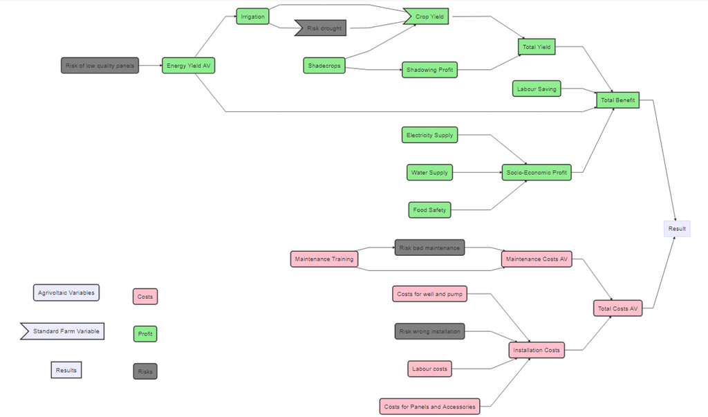

Figure 2.1: Conceptual Model

## 2.3 Stakeholders

A Stakeholder is “any group or individual who is affected by or can affect the achievement of an organization’s objectives” (Freeman and McVea 2001). Stakeholder management is needed to balance the interests of all stakeholders with regard to their positions. Different stakeholders can have varying influence, depending on their position, to the result of the project outcome. For this project, communication did not take place with all stakeholders, and there was also not enough data to plot all stakeholders in a graph depending on their willingness to cooperate, their interest in the final goal or their influence on the decision maker for example.

The project has local stakeholders as well as those from abroad in the form of development aid organizations (Fig. 2.2). To some extent, also the abroad government, as well as the population of the country and other groups that influence the decisions of the development aid organizations can be counted as stakeholders. At the local level there is the government, which becomes a stakeholder through political guidelines, but also through monetary grants. Many African countries are also striving for development goals, like the “Uganda Vision 2040” idea (“Uganda Vision 2040 – National Planning Authority” 2022). The Malian government also has those goals, which include the generation of electricity via solar energy (“Malian Agriculture: ‘Subsidies Need to Be Scaled up’” 2017). Future-oriented projects, like agrivoltaic systems, are therefore interesting for the government.

The projects are executed at farms, and therefore farmers play an important role in the question if those projects will succeed. A close communication between experts and farmers is essential to reduce risks, which could lead otherwise into difficulties. The addition of agrivoltaics aims to benefit not only the smallholder farmers directly, but also the surrounding community. An agrivoltaic system shared by smallholder farmers can lead to a close water access to new parts of rural areas. Other benefits for the community that can come with an agrivoltaic intervention are independent electricity, which can be used from charging mobile devices to cooling dairy products (Owusu-Kwarteng et al. 2020) or medication inside a refrigerator (Opiyo 2020). Photovoltaic supply companies play an important role while setting up an agrivoltaic systems. They need to contribute suitable solar panels devices, which can be installed and be maintained with the knowledge of locally available electricians. Those maintenance workers play a key role in the lifespan of those projects. And it is possible that with an increase in the use of solar panels, the number of learned electricians will also increase. An agrivoltaic intervention brings new growing conditions in the shade of the panels and irrigation possibilities with ground water pumps, which can be used to produce crops that would have been previously unable to grow. These new products can influence the local market place, transport processes or even nutrition deficits. More distant stakeholder are nearby communities, anyone who is groundwater dependent or power plant companies, although for stakeholder management these probably do not have to be considered.

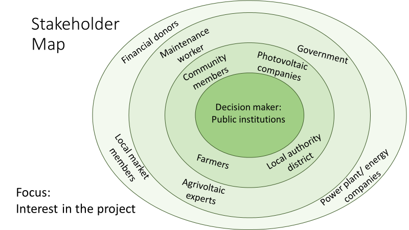

Figure 2.2: Stakeholder Overview

## 2.4 Input Estimates

The estimates are given in ranges with 90% certainty and normally distributed. To produce reliable estimates, calibration is needed. Becoming a calibrated estimator, can be achieved with calibration tests, that help to improve the ability to correctly estimate ranges. The goal is to examine the own tendencies of misjudging and to use the new found knowledge for self-improvement. Constant values in the case of the experiment duration for example are also valid inputs. In combination with the model function, the input estimates are then used to calculate the Monte-Carlo simulation. The estimates were collected with two different methods.

The base of our estimates originates from literature research, which was conducted on experiments and publications with adaptable scenarios to the project. Care was taken to ensure that comparable conditions existed or that the values were interpolated and adapted to our case. For the literature, publications about agrivoltaics mostly in western Africa were of highest interest, but also other literature about photovoltaic and developing aid were considered. Input ranges with the topic of agriculture were estimated with the help of publications like “New Climate-Smart Sorghum and Millet Varieties Improve Nutrition and Incomes of Malian Farmers – ICRISAT” (2022); “Mali Price Bulletin, April 2022 - Mali ReliefWeb” (2022); “Post Harvest Losses - Losses_estimates - for Crop Millets in Country Mali” (2017). For the variables regarding the topic of photovoltaic including costs, efficiency and production publications from “Agri-Photovoltaik: Chance für Landwirtschaft Und Energiewende - Fraunhofer ISE” (2022); Raza et al. (2022); Shouman, El Shenawy, and Badr (2016) were used. To estimate the ranges about the life and households in western Africa information was gathered in George Rapsomanikis (2015).

| variable | lower | upper | distribution | label | Description |
| --- | --- | --- | --- | --- | --- |
| av_int_no_involvement_by_population | 0.100 | 0.300 | posnorm | Probability of non-involvement of community [%] | Probability that the project fails due to non-involvement of the community in which the project is executed |
| av_int_no_involvement_by_institution | 0.500 | 0.200 | posnorm | Probability of non-involvement of institutions [%] | Probability that the project fails due to non-involvement of the institutions which should have helped with the execution of the project |
| av_int_event_photovoltaic_panels | 0.100 | 0.150 | posnorm | av_int_event_photovoltaic_panels | Probability for the event that the photovoltaic panels are damaged (not used at the moment) |
| av_risk_drought | 0.100 | 0.200 | posnorm | Risk of drought event [%] | Probability that a drought event occurs |
| av_effects_drought | 0.500 | 0.900 | posnorm | Effect of drought on yield [%] | Decrease of yield and effects on irrigation in percentage due to drought event |
| av_crop_ha | 0.800 | 0.800 | const | Farm area [ha] | Parts of the farm in which crops are growing in hectar |
| av_crop_yield_t_ha | 0.500 | 0.150 | posnorm | Yield millet [t/ha] | Yield of millet in tons per hectar |
| av_crop_profit_EUR_t | 380.000 | 530.000 | posnorm | Market price millet [€/t] | Market price of millet |
| av_ha | 0.005 | 0.005 | const | Area with panels [ha] | Area with photovoltaic panels in ha |
| av_energy_yield_kwp_ha | 9000.000 | 10000.000 | posnorm | Annual energy yield [kWh/ha] | Annual energy yield of the photovoltaic panels per hectar |
| av_energy_profit_EUR_kwp | 0.170 | 0.230 | posnorm | Energy price [€/kWh] | Grid energy price |
| av_int_cost_search_panels | 50.000 | 250.000 | posnorm | Costs for searching suitable panels [€] | Costs for the search of suitable photovoltaic panels |
| av_int_cost_search_location | 50.000 | 100.000 | posnorm | Costs for searching a suitable location [€] | Costs for the search of a suitable location for the panel installation |
| av_int_cost_photovoltaic_panels | 900000.000 | 1100000.000 | posnorm | All costs of AV facility [€/ha] | Costs for photovoltaic panels, ground preparation, construction… |
| yield_loss | 0.900 | 0.940 | posnorm | Remaining yield after harvest [%] | Remaining yield through post harvest losses in percent |
| av_int_cost_installation | 100.000 | 2000.000 | posnorm | Costs for installation [€] | Costs for installation of the agrivoltaic system |
| av_int_cost_training | 30.000 | 100.000 | posnorm | Costs for training [€] | Costs for training maintenance workers |
| av_int_cost_reparation | 50.000 | 300.000 | posnorm | Costs for reparation [€] | Costs for running reparation tasks |
| av_int_benefit_shade | 0.100 | 0.900 | posnorm | Shade benefit | Benefit of the shade of the panels in percent |
| discount | 1.000 | 5.000 | posnorm | Discount | Discount value for the model |
| vv_var | 5.000 | 20.000 | posnorm | Variance | Variance applied to the values in the model |
| n_years | 30.000 | 30.000 | const | Amount of years | Duration of the simulation in years |
| av_int_risk_installation | 0.100 | 0.200 | posnorm | Chance of installation errors [%] | Chance that errors occour during installation of AV facility |
| av_int_risk_installation_cost | 0.010 | 5.000 | posnorm | AV facility erroneous [%] | Percentage of installation that needs to be redone |
| av_int_risk_panellowquality | 0.050 | 0.100 | posnorm | Chance of low quality panels [%] | Chance that the AV panels are of low quality |
| av_int_risk_panellowquality_reduction | 0.700 | 0.950 | posnorm | Reduced energy yield [%] | Reduction of energy yield through low quality panels |
| labour_costs | 1.500 | 1.900 | posnorm | Labour costs [€/day] | Daily labour costs |
| annual_labour | 100.000 | 170.000 | posnorm | Annual labour [days/ha] | Annual labour per ha |
| av_int_labour_reduction | 0.700 | 0.950 | posnorm | Reduced labour [%] | Reduced labour through AV-irrigation |
| av_int_pump_energy | 0.150 | 0.180 | posnorm | Energy need pump [kWh/m^3] | Energy demand for pump per m^3 |
| av_int_annual_irrigation | 6000.000 | 8000.000 | posnorm | Annual irrigation [m^3/ha] | Average annual irrigation for a ha |
| av_int_irrigation_factor | 1.400 | 2.000 | posnorm | Increased yield [%] | Increased yield through irrigation |
| av_shadedcrop_yield | 0.500 | 1.000 | posnorm | Yield of AV crop [t/ha] | Crops that are grown under the AV panels |
| av_shadedcrop_profit | 850.000 | 1050.000 | posnorm | Market price of AV crop [€/t] | Price of crops that grown under AV panels |
| av_int_risk_maintenance | 0.050 | 0.300 | posnorm | Risk of bad maintenance [%] | Risk that AV facility is bad maintained |
| av_int_risk_maintenance_costs | 0.100 | 5.000 | posnorm | Additional maintenance costs [%] | Additional costs for reparation through bad maintenance |

## 2.5 Questionnaire

After we determined estimates for the input variables based on the literature research, we then decided to create a questionnaire to get more precise values. The idea was to send it to several experts who work on similar projects, have experience with photovoltaic systems or agriculture in Africa, as well as farmers in West Africa who could give us valuable information about current market prices and general agricultural conditions.

The questionnaire included agricultural related questions (e.g. “Estimate the impact of a severe drought on the yield of millet in [%] on a standard farm.”), technical questions about the photovoltaic system (e.g.’’Estimate the potential annual costs for general maintenance of an agrivoltaic system (e.g. repairs, cleaning, preventive maintenance etc.)”) as well as questions related to irrigation (e.g. ”Estimate the potential yield increase in [%] with an irrigation system.”). It was structured so that the participants had to estimate a range for each variable and were able to skip the questions they were not certain about. We contacted a number of experts, but unfortunately not many participants completed the questionnaire.

## 2.6 Code

The code generates two Monte Carlo simulation outcomes and is affected by multiple variables from the ‘av_estimates’ table. One outcome represents a farm with AV intervention and one outcome a reference farm. Further the AV intervention is split into planning, setup and execution parts. The outcomes are based on a time series analysis for 30 years and 6000 simulations.

### 2.6.1 Variability

Some variables vary over the 30 years of simulation. This variation was created with the ‘vv’ function and the variable ‘vv_var’ which represents a coefficient of variation. ‘vv_var’ has a lower and upper bound of 5% and 20%.

### 2.6.2 Chance events

Risks were included as chance events with the ‘chance_event’ function. Two of those risks were missing input of the population or institutions which would lead to a failure of the project. This would result in planning costs and no benefits through the AV system.

Further risks are ‘bad quality of photo voltaic panels’ resulting in a lower energy yield than expected, ‘bad installation’ of the panels and ‘bad maintenance’ both resulting in higher maintenance costs and ‘droughts.’ The first three risks reduce the benefits of the AV intervention while ‘drought’ only has a reducing effect on farms without AV intervention through missing irrigation opportunities.

```r
# data preparation
input_estimates <- read.csv("data/av_estimates_overview.csv", header = TRUE)




model_function <- function(){


  # ex-ante risks
  av_int_event_no_involvement_by_population <-
    chance_event(av_int_no_involvement_by_population, 1, 0, n = 1)
  av_int_event_no_involvement_by_institution <-
    chance_event(av_int_no_involvement_by_institution, 1, 0, n = 1)




  # processing through standard farm and farm with av intervention
  for (decision_av_int in c(FALSE, TRUE))
  {


    if (decision_av_int)
    {
      decision_av_int_planning <- TRUE
      decision_av_int_setup <- TRUE
      decision_av_int_execution <- TRUE
    }

    else
    {
      decision_av_int_planning <- FALSE
      decision_av_int_setup <- FALSE
      decision_av_int_execution <- FALSE
    }



    # if project fails due to no involvement only planning costs remain
    if (av_int_event_no_involvement_by_population)
    {
      decision_av_int_setup <- FALSE
      decision_av_int_execution <- FALSE
    }

    if (av_int_event_no_involvement_by_institution)
    {
      decision_av_int_setup <- FALSE
      decision_av_int_execution <- FALSE
    }





    ### cost calculation

    ## calculation planning costs
    if (decision_av_int_planning)
    {
      av_int_planning <- av_int_cost_search_panels + av_int_cost_search_location
    }
    else
    {
      av_int_planning <- 0
    }



    ## calculation of setup costs
    if (decision_av_int_setup)
    {
      # panel costs
      var_panel_cost = (av_int_cost_photovoltaic_panels * av_ha)

      # installation costs and risks
      var_installation_risk_cost = chance_event(chance = av_int_risk_installation,
                                                value_if = vv(av_int_risk_installation_cost, vv_var, n = 1) *
                                                  av_int_cost_installation, value_if_not = 0, n = 1)

      # total setup costs for AV intervention
      av_int_setup <- var_panel_cost +
        av_int_cost_installation +
        var_installation_risk_cost +
        av_int_cost_training
    }

    else
    {
      av_int_setup <- 0
    }



    ## calculation execution/maintenance costs
    if (decision_av_int_execution)
    {
      # cost for repairing the AV facility and maintaining costs through bad maintenance
      av_int_execution <- vv(av_int_cost_reparation, vv_var, n_years) *
        chance_event(chance = av_int_risk_maintenance,
                     value_if = vv(av_int_risk_maintenance_costs, vv_var, 1),
                     value_if_not = 1, n = n_years)
    }
    else
    {
      av_int_execution <- 0
    }



    ## calculation of labor costs
    if (decision_av_int_execution)
    {
      # labor costs reduction through AV intervention
      var_labour_reduction <- vv(av_int_labour_reduction, vv_var, n_years)
    }

    else
    {
      # if no AV intervention labor intensity stays at 100%
      var_labour_reduction <- vv(c(1, 1), c(0, 0), n_years)
    }

    # total labor costs
    var_labour_costs <- var_labour_reduction *
      vv(av_crop_ha, c(0, 0), n_years) *
      vv(annual_labour, vv_var, n_years) *
      vv(labour_costs, vv_var, n_years)



    ## calculating total costs

    # for all years
    av_int_cost <- av_int_execution  + var_labour_costs

    # additionally for the first year due to setup and planning costs
    av_int_cost[1] <- av_int_cost[1] + av_int_setup + av_int_planning




    ### benefit calculations



    ## calculating energy yield

    # risk of low quality panels
    var_lowpanelquality_risk_reduction = chance_event(chance = av_int_risk_panellowquality,
                                                      value_if = vv(av_int_risk_panellowquality_reduction,
                                                                    vv_var, n = 1,
                                                                    upper_limit = 1),
                                                      value_if_not = 1, n = 1)

    # total energy yield
    av_energy_yield <-  vv(av_ha, c(0, 0), 1) *
      vv(av_energy_yield_kwp_ha,
         vv_var,
         n_years,
         relative_trend = -(panel_performance_reduction * 100)) * var_lowpanelquality_risk_reduction

    # total energy consumption from pump
    av_energy_pump <-   vv(av_int_annual_irrigation, vv_var, n_years) *
      vv(av_int_pump_energy, vv_var, n_years) *
      vv(av_crop_ha, c(0, 0), n_years)

    # calculating variables if energy demand for irrigation is higher than energy yield
    # this does not have an effect on irrigation yet. Only prevents a negative energy yield
    # which would result in costs for energy
    if (av_energy_pump > av_energy_yield)
    {
      av_energy_pump <- av_energy_yield
    }

    # total energy profit
    var_av_energy_profit <- (av_energy_yield - av_energy_pump) * av_energy_profit_EUR_kwp



    ## calculating crop yield

    # calculating factors for yield through irrigation, drought risk and shaded crop yield
    if (decision_av_int_execution)
    {
      var_irrigation_factor <- vv(av_int_irrigation_factor, vv_var, n_years)
      # drought has no effect in the model on the AV farm. Factor stays 1
      var_risk_effectdrought <- vv(c(1, 1), c(0, 0), n_years)
      var_shadedcrop_yield <- vv(av_shadedcrop_yield, vv_var, n_years)
    }

    else
    {
      # reference farm has no irrigation. Factor stays 1
      var_irrigation_factor <- vv(c(1, 1), c(0, 0), n_years)
      var_risk_effectdrought <- chance_event(chance = av_risk_drought,
                                             value_if = vv(av_effects_drought, vv_var, 1),
                                             value_if_not = 1, n = n_years)
      # no shaded crops in reference farm
      var_shadedcrop_yield <- vv(c(0, 0), c(0, 0), n_years)
    }

    # total crop yield
    av_crop_yield <-  vv(av_crop_ha, c(0, 0), n_years) *
      vv(av_crop_yield_t_ha, vv_var, n_years) *
      vv(av_crop_profit_EUR_t, vv_var, n_years) *
      var_irrigation_factor *
      var_risk_effectdrought +
      var_shadedcrop_yield *
      vv(av_shadedcrop_profit, vv_var, n_years) *
      vv(av_ha, c(0, 0), n_years)



    ## calculating total benefits

    if(decision_av_int_execution)
    {
      total_benefits <- av_crop_yield + var_av_energy_profit
    }

    else
    {
      total_benefits <- av_crop_yield
    }




    ### calculating results (benefits - costs)


    # for reference farm
    if (!decision_av_int)
    {
      net_benefits <- total_benefits - av_int_cost
      result <- net_benefits
    }

    # for AV farm
    if (decision_av_int)
    {
      net_benefits <- total_benefits - av_int_cost+ vv(c(333, 333), c(0, 0), n_years)
      result_int <- net_benefits
    }
  }


  # calculating net present value (NPV)
  NPV <- discount(result, discount, calculate_NPV = TRUE)
  NPV_int <- discount(result_int, discount, calculate_NPV = TRUE)



  # Generate the list of outputs from the Monte Carlo simulation
  return(list(NPV = NPV,
              NPV_int = NPV_int,
              NPV_decision = NPV_int - NPV,
              Cashflow_decision = result_int - result))
}


# Run the Monte Carlo simulation using the model function
example_mc_simulation <- mcSimulation(estimate = as.estimate(input_estimates),
                                      model_function = model_function,
                                      numberOfModelRuns = 6000,
                                      functionSyntax = "plainNames")
```

# 3 **Results and Discussion**

## 3.1 Net Present Value (NPV) distributions

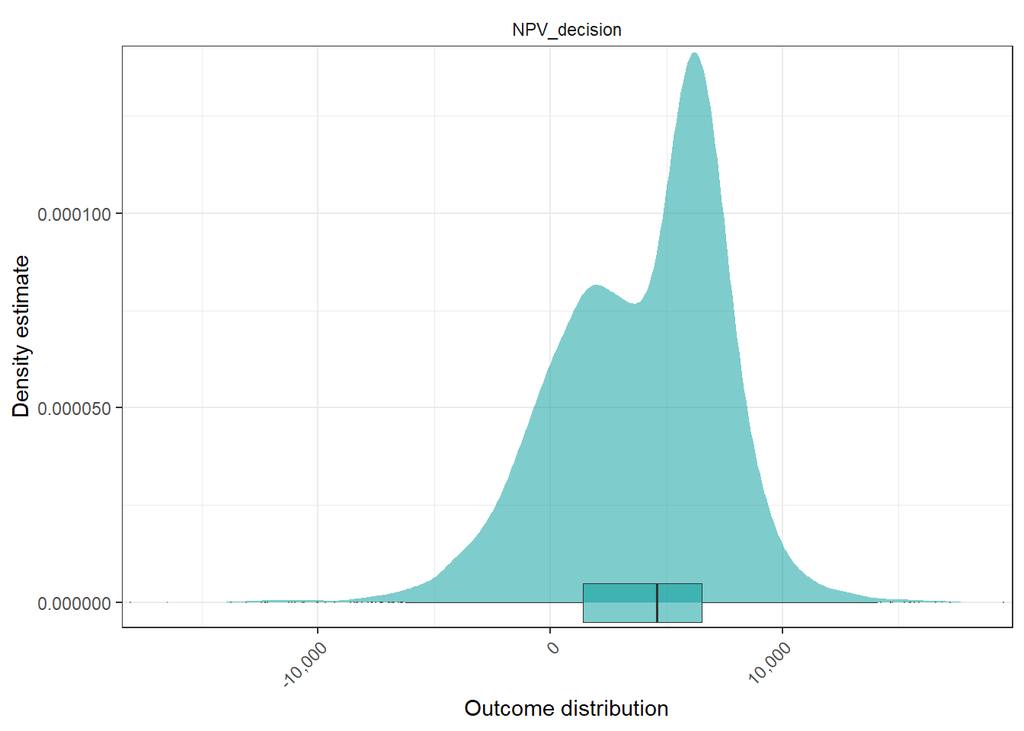

Figure 3.1: Difference in NPV between Intervention and no Intervention

## 3.2 EVPI, VIP, Cashflow

The expected value of perfect information (EVPI) is an estimation of the monetary value for any additional information that reduces uncertainty for specific variables in the model. It was calculated to identify the variables for which further information could be beneficial in order to increase certainty of the decision.

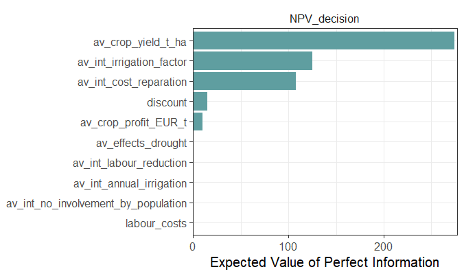

Figure 3.2: The EVPI is the estimated amount of money to gain perfect information about a given variable

With the PLS analysis the variable importance in projection (VIP) can be calculated. The VIP scores represent the sensitivity of the model on each variable.

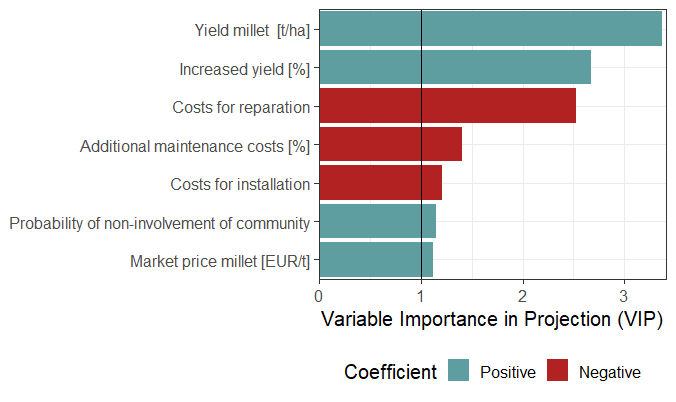

Figure 3.3: VIP Scores, indicating the importance of each variable in the model (Threshold of the VIP = 1)

Figure 3.4 shows the annual cashflow over the whole period of the simulation. In our model the cashflow is rather low, likely due to the low estimations for revenues of the additional crop, which is grown under the photovoltaic modules. Overall the returns are steady but just above the zero mark for each year, and only a small chance (5% quantile) for a negative cashflow.

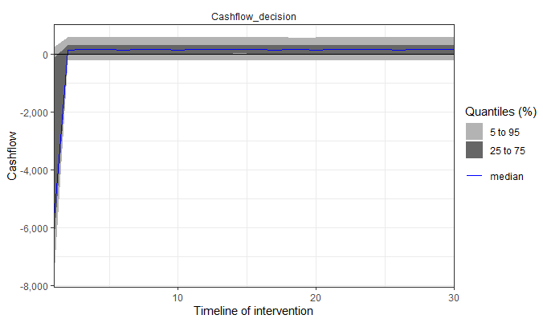

Figure 3.4: Annual Cashflow for 30 years